# Yiel Crop Model

Franklin Santos

9/8/2020

## Antecedentes

Últimamente he publicado screencasts que demuestran cómo utilizar el marco tidymodels, desde el comienzo hasta el ajuste de modelos más complejos. El screencast de hoy explora cómo aplicar con fluidez los principios de datos ordenados a la tarea de construir muchos modelos usando el conjunto de datos #TidyTuesday de esta semana sobre el rendimiento de los cultivos. 🌽

Este publicación tiene un tutorial en YouTube por Jualia Silge “https://www.youtube.com/watch?v=rhhuNGjj3cU”

Aquí está el código que utilicé en el video, para aquellos que prefieren leer en lugar o además del video.

## Exploración de datos

Nuestro objetivo de modelado es estimar cómo están cambiando los [rendimientos de los cultivos en todo el mundo utilizando el conjunto de datos #TidyTuesday https://github.com/rfordatascience/tidytuesday/blob/master/data/2020/2020-09-01/readme.md] de esta semana. Podemos construir muchos modelos para las combinaciones país-cultivo que nos interesan.

Primero, leamos dos de los conjuntos de datos de esta semana.

```r
library(tidyverse)
key_crop_yields <- read_csv("https://raw.githubusercontent.com/rfordatascience/tidytuesday/master/data/2020/2020-09-01/key_crop_yields.csv")
land_use <- read_csv("https://raw.githubusercontent.com/rfordatascience/tidytuesday/master/data/2020/2020-09-01/land_use_vs_yield_change_in_cereal_production.csv")
```

Usaré el conjunto de datos land_use solo para encontrar los países con mayor población. Creemos un vector de sus nombres.

```r
top_countries <- land_use %>%
  janitor::clean_names() %>%
  filter(!is.na(code), entity != "World") %>%
  group_by(entity) %>%
  filter(year == max(year)) %>%
  ungroup() %>%
  slice_max(total_population_gapminder, n = 30) %>%
  pull(entity)

top_countries
```

```
##  [1] "China"                        "India"
##  [3] "United States"                "Indonesia"
##  [5] "Pakistan"                     "Brazil"
##  [7] "Nigeria"                      "Bangladesh"
##  [9] "Russia"                       "Mexico"
## [11] "Japan"                        "Ethiopia"
## [13] "Philippines"                  "Egypt"
## [15] "Vietnam"                      "Democratic Republic of Congo"
## [17] "Germany"                      "Turkey"
## [19] "Iran"                         "Thailand"
## [21] "United Kingdom"               "France"
## [23] "Italy"                        "South Africa"
## [25] "Tanzania"                     "Myanmar"
## [27] "Kenya"                        "South Korea"
## [29] "Colombia"                     "Spain"
```

Ahora creemos una versión ordenada de los datos de rendimiento de los cultivos, para los países y cultivos que me interesan.

```r
tidy_yields <- key_crop_yields %>%
  janitor::clean_names() %>%
  pivot_longer(wheat_tonnes_per_hectare:bananas_tonnes_per_hectare,
    names_to = "crop", values_to = "yield"
  ) %>%
  mutate(crop = str_remove(crop, "_tonnes_per_hectare")) %>%
  filter(
    crop %in% c("wheat", "rice", "maize", "barley"),
    entity %in% top_countries,
    !is.na(yield)
  )

tidy_yields
```

```
## # A tibble: 6,032 x 5
##    entity     code   year crop   yield
##    <chr>      <chr> <dbl> <chr>  <dbl>
##  1 Bangladesh BGD    1961 wheat  0.574
##  2 Bangladesh BGD    1961 rice   1.70
##  3 Bangladesh BGD    1961 maize  0.799
##  4 Bangladesh BGD    1961 barley 0.577
##  5 Bangladesh BGD    1962 wheat  0.675
##  6 Bangladesh BGD    1962 rice   1.53
##  7 Bangladesh BGD    1962 maize  0.738
##  8 Bangladesh BGD    1962 barley 0.544
##  9 Bangladesh BGD    1963 wheat  0.607
## 10 Bangladesh BGD    1963 rice   1.77
## # … with 6,022 more rows
```

¡Esta estructura de datos es perfecta para graficar el **rendimiento del cultivo a lo largo del tiempo!**

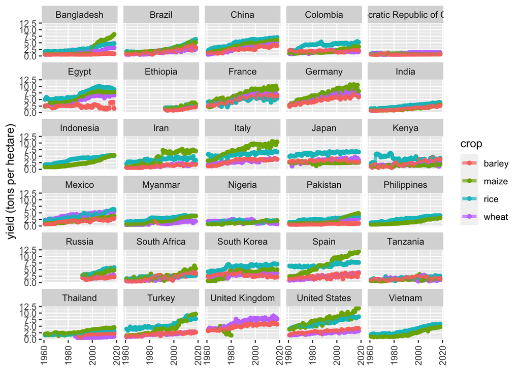

```r
tidy_yields %>%
  ggplot(aes(year, yield, color = crop)) +
  geom_line(alpha = 0.7, size = 1.5) +
  geom_point() +
  facet_wrap(~entity, ncol = 5) +
  scale_x_continuous(guide = guide_axis(angle = 90)) +
  labs(x = NULL, y = "yield (tons per hectare)")
```

Tenga en cuenta que no todos los países producen todos los cultivos, pero que el rendimiento general de los cultivos está *aumentando*.

## Muchos modelos

Ahora ajustemos un modelo lineal a cada combinación de cultivo y país.

```r
library(tidymodels)
```

```r
tidy_lm <- tidy_yields %>%
  nest(yields = c(year, yield)) %>%
  mutate(model = map(yields, ~ lm(yield ~ year, data = .x)))

tidy_lm
```

```
## # A tibble: 111 x 5
##    entity     code  crop   yields            model
##    <chr>      <chr> <chr>  <list>            <list>
##  1 Bangladesh BGD   wheat  <tibble [58 × 2]> <lm>
##  2 Bangladesh BGD   rice   <tibble [58 × 2]> <lm>
##  3 Bangladesh BGD   maize  <tibble [58 × 2]> <lm>
##  4 Bangladesh BGD   barley <tibble [58 × 2]> <lm>
##  5 Brazil     BRA   wheat  <tibble [58 × 2]> <lm>
##  6 Brazil     BRA   rice   <tibble [58 × 2]> <lm>
##  7 Brazil     BRA   maize  <tibble [58 × 2]> <lm>
##  8 Brazil     BRA   barley <tibble [58 × 2]> <lm>
##  9 China      CHN   wheat  <tibble [58 × 2]> <lm>
## 10 China      CHN   rice   <tibble [58 × 2]> <lm>
## # … with 101 more rows
```

A continuación, vamos a ordenar con tidy() esos modelos para obtener los coeficientes y ajustar los valores p para múltiples comparaciones mientras estamos en ello.

```r
slopes <- tidy_lm %>%
  mutate(coefs = map(model, tidy)) %>%
  unnest(coefs) %>%
  filter(term == "year") %>%
  mutate(p.value = p.adjust(p.value))

slopes
```

```
## # A tibble: 111 x 10
##    entity  code  crop  yields  model term  estimate std.error statistic  p.value
##    <chr>   <chr> <chr> <list>  <lis> <chr>    <dbl>     <dbl>     <dbl>    <dbl>
##  1 Bangla… BGD   wheat <tibbl… <lm>  year   0.0389   0.00253      15.4  5.11e-20
##  2 Bangla… BGD   rice  <tibbl… <lm>  year   0.0600   0.00231      26.0  6.05e-31
##  3 Bangla… BGD   maize <tibbl… <lm>  year   0.122    0.0107       11.3  1.82e-14
##  4 Bangla… BGD   barl… <tibbl… <lm>  year   0.00505  0.000596      8.47 4.34e-10
##  5 Brazil  BRA   wheat <tibbl… <lm>  year   0.0366   0.00222      16.5  2.55e-21
##  6 Brazil  BRA   rice  <tibbl… <lm>  year   0.0755   0.00490      15.4  4.96e-20
##  7 Brazil  BRA   maize <tibbl… <lm>  year   0.0709   0.00395      18.0  4.37e-23
##  8 Brazil  BRA   barl… <tibbl… <lm>  year   0.0466   0.00319      14.6  5.05e-19
##  9 China   CHN   wheat <tibbl… <lm>  year   0.0880   0.00141      62.6  1.72e-51
## 10 China   CHN   rice  <tibbl… <lm>  year   0.0843   0.00289      29.2  1.47e-33
## # … with 101 more rows
```

## Explorar resultados

Ahora podemos visualizar los resultados de este modelo, que está estimando cómo están cambiando los rendimientos de los cultivos en todo el mundo.

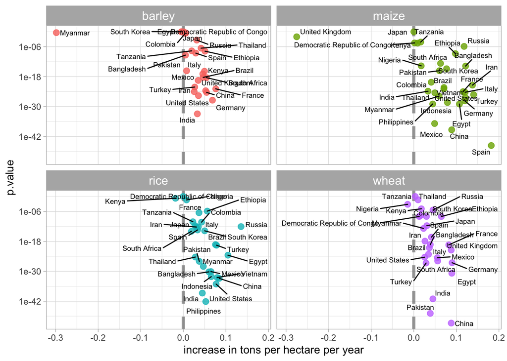

```r
#library(ggrepel)
#slopes %>%
 # ggplot(aes(estimate, p.value, label = entity)) +
  #geom_vline(
   # xintercept = 0, lty = 2,
    #size = 1.5, alpha = 0.7, color = "gray50"
  #) +
  #geom_point(aes(color = crop), alpha = 0.8, size = 2.5, show.legend = FALSE) +
  #scale_y_log10() +
  #facet_wrap(~crop) +
  #geom_text_repel(size = 3, family = "IBMPlexSans") +
  #theme_light(base_family = "IBMPlexSans") +
  #theme(strip.text = element_text(family = "IBMPlexSans-Bold", size = 12)) +
  #labs(x = "increase in tons per hectare per year")

# Modified model function
library(ggrepel)
slopes %>%
  ggplot(aes(estimate, p.value, label = entity)) +
  geom_vline(
    xintercept = 0, lty = 2,
    size = 1.5, alpha = 0.7, color = "gray50") +
  geom_point(aes(color = crop), alpha = 0.8, size = 2.5, show.legend = FALSE) +
  scale_y_log10() +
  facet_wrap(~crop) +
  geom_text_repel(size = 2.5) +
  theme_light() +
  theme(strip.text = element_text(size = 12)) +
  labs(x = "increase in tons per hectare per year")
```

- En el eje-x está la pendiente de estos modelos. Tenga en cuenta que la mayoría de los países están en el lado positivo, con rendimientos de cultivos en aumento. Cuanto más a la derecha esté un país, mayor será el aumento del rendimiento de los cultivos durante este período de tiempo. Los rendimientos de maíz son los que más han aumentado.
- En el eje-y está el valor p, una medida de cuán sorprendente es el efecto que vemos bajo el supuesto de que no hay relación (sin cambios con el tiempo). Los países más bajos en las parcelas tienen valores p más pequeños; estamos más seguros de que se trata de relaciones reales.

Podemos ampliar esto para comprobar qué tan bien estos modelos se ajustan a los datos con glance(). ¡Este enfoque para usar modelos estadísticos para estimar cambios en muchos subgrupos a la vez me ha sido muy útil en muchas situaciones!